# Reimagine the R package distribution system for reproducible research and submissions

November 4, 2021

## Disclaimer

All opinions expressed are those of the presenter and not Merck Sharp & Dohme Corp., a subsidiary of Merck & Co., Inc., Kenilworth, NJ, USA.

## Agenda

- pkglite: compact package representations
- cleanslate: portable R environments
- pkglink: runtime package resolution

## Reimagine the way to represent an R package

- A **tool** for packing and restoring R packages as plaintext assets that are easy to store, transfer, and review
- A **grammar** for specifying the file packing scope that is functional, precise, and extendable
- A **standard** for exchanging the packed asset that is unambiguous, human-friendly, and machine-readable

## pkglite: compact package representations

pkglite is available from CRAN

```r
library("pkglite")

"/path/to/pkg/" %>%
  collate(file_ectd(), file_auto("inst/")) %>%
  pack()

pack(
  "/path/to/pkg1/" %>% collate(file_ectd()),
  "/path/to/pkg2/" %>% collate(file_ectd()),
  output = "/path/to/pkglite.txt"
)

"/path/to/pkglite.txt" %>% unpack(output = "/path/to/output/", install = TRUE)
```

Website: https://merck.github.io/pkglite/

## Reimagine the R environment to use R packages

- Create a project folder with specific context (`.Rproj`, `.Rprofile`, `.Renviron`)
- Install a specific version of R into the project folder
- Install a specific version of Rtools into the project folder
- (without administrator privileges)

## cleanslate: portable R environments

```r
library("cleanslate")

"portable-project/" %>%
  use_project(repo = "https://url/snapshot/2021-11-04/") %>%
  use_rprofile() %>%
  use_renviron() %>%
  use_r_version(version = "4.1.1") %>%
  use_rtools(version = "rtools40")
```

(Under validation)

## Reimagine the way to distribute and import R packages

- Infrastructure-free: install and load packages from any remote or local files, without CRAN-like repos or Git servers
- Package aliasing: compile, install, and load packages with aliases at runtime
- Vectorized loading: install and load multiple packages with one line of code

## pkglink: runtime package resolution

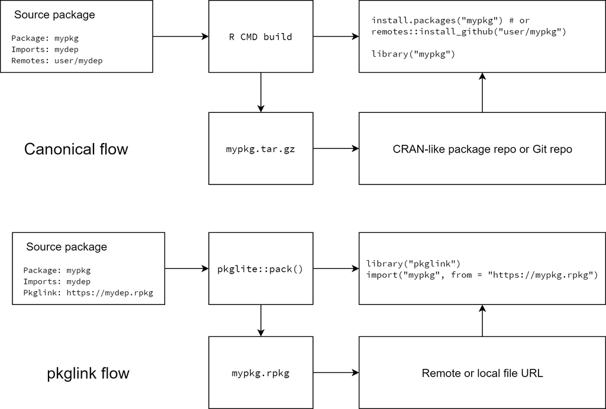

## pkglink grammar

Single package from remote URL:

```r
pkglink::import("mypkg", from = "https://url/mypkg@0.2.0.rpkg")
```

Local file and with alias:

```r
pkglink::import("mypkg", as = "yourpkg", from = "/path/to/mypkg.rpkg")
```

Multiple packages but selectively:

```r
pkglink::import(c("mypkg1", "mypkg3"), from = "https://url/mypkgs.rpkg")
```

Multiple packages with aliases:

```r
pkglink::import(c("mypkg1", "mypkg2"), as = c("yourpkg1", "yourpkg2"), from = "mypkgs.rpkg")
```

(In development)

## Thank you

**Email:** nan.xiao1@merck.com